# Precept 5 Exercise

where $l_{i}$ is the sepal length of a given plant and `set`, `ver`, and `vir` refer to the respective species. How should you interpret the output from each of these models? Are the results any better than the previous model? Use the $R^2$ and $R^2_{adj}$ in your argument. (Preceptors: please explain the meanings of the coefficients and how the meanings are different for the two models.)

```r
# Multiple regression
mod3 <- lm(Sepal.Width ~ Sepal.Length + Species, data=iris)
summary(mod3)

Call:
lm(formula = Sepal.Width ~ Sepal.Length + Species, data = iris)

Residuals:
     Min       1Q   Median       3Q      Max
-0.95096 -0.16522  0.00171  0.18416  0.72918

Coefficients:
                  Estimate Std. Error t value Pr(>|t|)
(Intercept)        1.67650    0.23536   7.123 4.46e-11 ***
Sepal.Length       0.34988    0.04630   7.557 4.19e-12 ***
Speciesversicolor -0.98339    0.07207 -13.644  < 2e-16 ***
Speciesvirginica  -1.00751    0.09331 -10.798  < 2e-16 ***
---
Signif. codes:  0 '***' 0.001 '**' 0.01 '*' 0.05 '.' 0.1 ' ' 1

Residual standard error: 0.289 on 146 degrees of freedom
Multiple R-squared:  0.5693,    Adjusted R-squared:  0.5604
F-statistic: 64.32 on 3 and 146 DF,  p-value: < 2.2e-16

mod4 <- lm(Sepal.Width ~ Sepal.Length + Species + 0, data=iris)
summary(mod4)

Call:
lm(formula = Sepal.Width ~ Sepal.Length + Species + 0, data = iris)

Residuals:
     Min       1Q   Median       3Q      Max
-0.95096 -0.16522  0.00171  0.18416  0.72918

Coefficients:
                  Estimate Std. Error t value Pr(>|t|)
Sepal.Length        0.3499     0.0463   7.557 4.19e-12 ***
Speciessetosa       1.6765     0.2354   7.123 4.46e-11 ***
Speciesversicolor   0.6931     0.2779   2.494   0.0137 *
Speciesvirginica    0.6690     0.3078   2.174   0.0313 *
---
Signif. codes:  0 '***' 0.001 '**' 0.01 '*' 0.05 '.' 0.1 ' ' 1

Residual standard error: 0.289 on 146 degrees of freedom
Multiple R-squared:  0.9915,    Adjusted R-squared:  0.9912
F-statistic:  4245 on 4 and 146 DF,  p-value: < 2.2e-16
```

Graphical interpretation of what these models mean; note that both model 3 and 4 give the same set of lines.

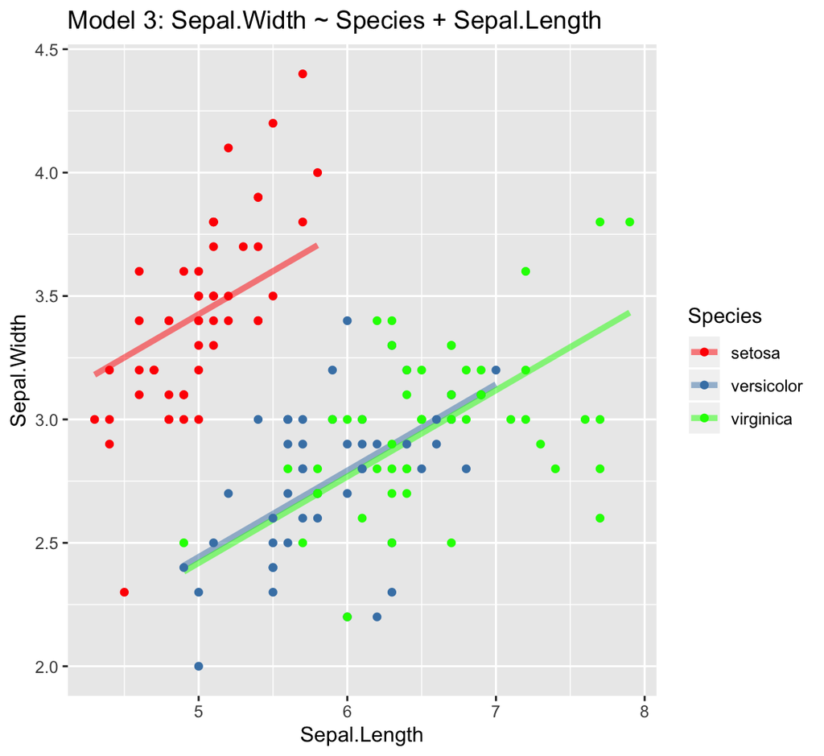

```r
# Plot data with the predicted models
# Prepare data frame for the graphs
fits <- data.frame(Sepal.Length=iris$Sepal.Length,
                   Sepal.Width=iris$Sepal.Width,
                   mod3=mod3$fitted.values,
                   mod4=mod4$fitted.values,
                   Species=iris$Species)

# Add the lines defined by the fitted mod3 to the scatterplot
ggplot(data = fits) +
  geom_line(aes(x=Sepal.Length, y=mod3, color=Species), size=1.5, alpha=0.5) +
  geom_point(aes(x=Sepal.Length, y=Sepal.Width, color=Species)) +
  scale_color_manual(values = c("red", "steelblue", "green")) +
  labs(x="Sepal.Length", y="Sepal.Width",
  title = "Model 3: Sepal.Width ~ Species + Sepal.Length")
```

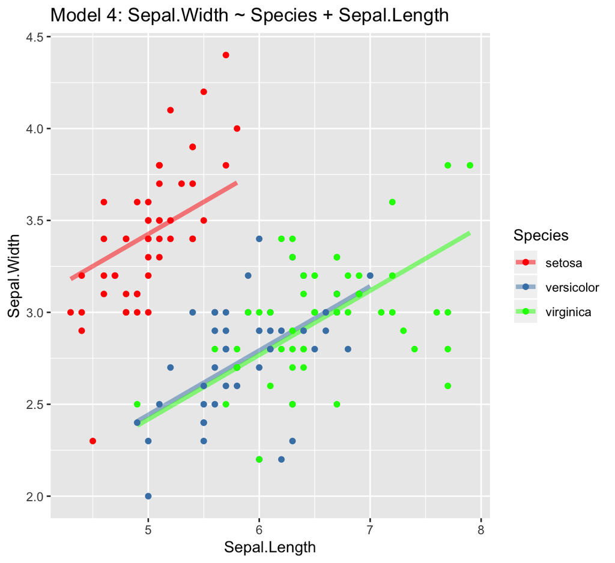

```r
# Add the lines defined by the fitted mod4 to the scatterplot
ggplot(data = fits) +
  geom_line(aes(x=Sepal.Length, y=mod4, color=Species), size=1.5, alpha=0.5) +
  geom_point(aes(x=Sepal.Length, y=Sepal.Width, color=Species)) +
  scale_color_manual(values = c("red", "steelblue", "green")) +
  labs(x="Sepal.Length", y="Sepal.Width",
  title = "Model 4: Sepal.Width ~ Species + Sepal.Length")
```

4. Now calculate the correlation within each species. Then, replace $sepal\ length$ with the interaction term, $sepal\ length \times species$, in model 4; find the regression line predicting the $sepal\ width$ of a iris with given $sepal\ length$ and $species$ values. That is; find the fitted model:
   $$\begin{align*}
   \hat{y}&=\hat{\beta}_{set}\cdot\mathbf{1}_{set}+\hat{\beta}_{ver}\cdot\mathbf{1}_{ver}+\hat{\beta}_{vir}\cdot\mathbf{1}_{vir} \\
   &\qquad+\hat{\beta}_{l\cdot set}\cdot l_{i}\cdot\mathbf{1}_{set}+\hat{\beta}_{l\cdot ver}\cdot l_{i}\cdot\mathbf{1}_{ver}+\hat{\beta}_{l\cdot vir}\cdot l_{i}\cdot\mathbf{1}_{vir}
   \end{align*}$$

Preceptors and students: you do not need to worry about the details in the code chunk below. You just need to know that within-group-correlations between ‘Sepal.Length’ and ‘Sepal.Width’ are 0.74, 0.53, 0.46 for the species setosa, versicolor and virginica, respectively.

```r
# Get correlations
corr.spec <- by(iris[,c('Sepal.Length', 'Sepal.Width')],
               INDICES= iris$Species,
               FUN=cor)
corr.spec
iris$Species: setosa
             Sepal.Length Sepal.Width
Sepal.Length    1.0000000   0.7425467
Sepal.Width     0.7425467   1.0000000
-----------------------------------------------
iris$Species: versicolor
             Sepal.Length Sepal.Width
Sepal.Length    1.0000000   0.5259107
Sepal.Width     0.5259107   1.0000000
-----------------------------------------------
iris$Species: virginica
             Sepal.Length Sepal.Width
Sepal.Length    1.0000000   0.4572278
Sepal.Width     0.4572278   1.0000000

# What by() does:
?by

# Careful how you use the output:
class(corr.spec)
[1] "by"
class(corr.spec[1])
[1] "list"
class(corr.spec[[1]])
[1] "matrix"
# Extacting out the within-species
# correlation between 'Sepal.Length' and 'Sepal.Width'
sapply(corr.spec, FUN=function(x){x[1,2]})
    setosa versicolor  virginica
 0.7425467  0.5259107  0.4572278
```

The correlation between `Sepal.Length` and `Sepal.Width` is much stronger within each group compare to that for the entire dataset. As a result it will be good to use different lines to make predictions for each group.

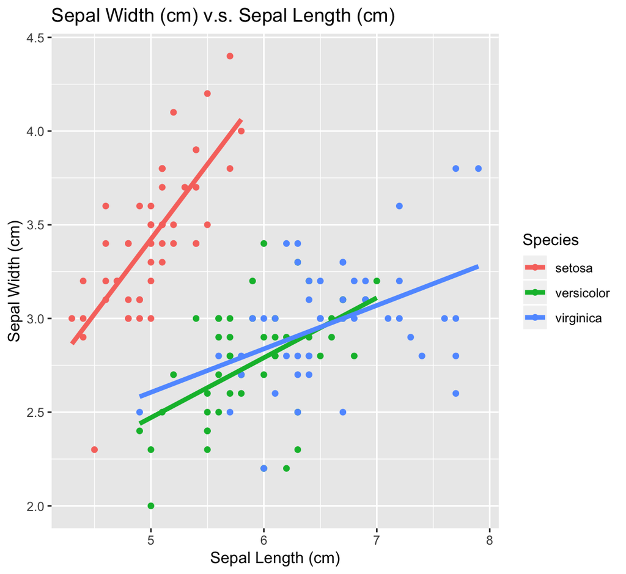

```r
# Fit the model; "+ 0" means do not include beta_0
# (i.e., no overall y-intercept for the model); you can also use "-1"
# to achieve the same result
mod5 <- lm(Sepal.Width ~ Species + Sepal.Length:Species + 0, data=iris)
summary(mod5)

Call:
lm(formula = Sepal.Width ~ Species + Sepal.Length:Species + 0,
    data = iris)

Residuals:
     Min       1Q   Median       3Q      Max
-0.72394 -0.16327 -0.00289  0.16457  0.60954

Coefficients:
                               Estimate Std. Error t value
Speciessetosa                  -0.56943    0.55386  -1.028
Speciesversicolor               0.87215    0.44906   1.942
Speciesvirginica                1.44631    0.40491   3.572
Speciessetosa:Sepal.Length      0.79853    0.11037   7.235
Speciesversicolor:Sepal.Length  0.31972    0.07537   4.242
Speciesvirginica:Sepal.Length   0.23189    0.06118   3.790
                               Pr(>|t|)
Speciessetosa                  0.305622
Speciesversicolor              0.054072 .
Speciesvirginica               0.000482 ***
Speciessetosa:Sepal.Length     2.55e-11 ***
Speciesversicolor:Sepal.Length 3.95e-05 ***
Speciesvirginica:Sepal.Length  0.000221 ***
---
Signif. codes:  0 '***' 0.001 '**' 0.01 '*' 0.05 '.' 0.1 ' ' 1

Residual standard error: 0.2723 on 144 degrees of freedom
Multiple R-squared:  0.9925,    Adjusted R-squared:  0.9922
F-statistic:  3190 on 6 and 144 DF,  p-value: < 2.2e-16

# Plot data with the predicted model
ggplot(data=iris,
       mapping = aes(x=Sepal.Length, y=Sepal.Width, color=Species)) +
  geom_point() +
  geom_smooth(method = "lm", se=F, size = 1.5, alpha=.5) +
  ggtitle("Sepal Width (cm) v.s. Sepal Length (cm)") +
  labs(x="Sepal Length (cm)", y="Sepal Width (cm)")
```

5. What happens if you use the `*` operator in lieu of the `:` operator in the model?

```r
# Regress model
mod6 <- lm(Sepal.Width ~ Sepal.Length*Species + 0, data=iris)
summary(mod6)

Call:
lm(formula = Sepal.Width ~ Sepal.Length * Species + 0, data = iris)

Residuals:
     Min       1Q   Median       3Q      Max
-0.72394 -0.16327 -0.00289  0.16457  0.60954

Coefficients:
                               Estimate Std. Error t value
Sepal.Length                     0.7985     0.1104   7.235
Speciessetosa                   -0.5694     0.5539  -1.028
Speciesversicolor                0.8721     0.4491   1.942
Speciesvirginica                 1.4463     0.4049   3.572
Sepal.Length:Speciesversicolor  -0.4788     0.1337  -3.582
Sepal.Length:Speciesvirginica   -0.5666     0.1262  -4.490
                               Pr(>|t|)
Sepal.Length                   2.55e-11 ***
Speciessetosa                  0.305622
Speciesversicolor              0.054072 .
Speciesvirginica               0.000482 ***
Sepal.Length:Speciesversicolor 0.000465 ***
Sepal.Length:Speciesvirginica  1.45e-05 ***
---
Signif. codes:  0 '***' 0.001 '**' 0.01 '*' 0.05 '.' 0.1 ' ' 1

Residual standard error: 0.2723 on 144 degrees of freedom
Multiple R-squared:  0.9925,    Adjusted R-squared:  0.9922
F-statistic:  3190 on 6 and 144 DF,  p-value: < 2.2e-16
```